# KoLab R Study Week4

May 2, 2019

## Week4

## Data loading

```r
library(readxl)
setwd("E:/Dropbox/study/R_study/19.03.28_R_study (Kolab)")
w3 <- read_xlsx("Week3_example1.xlsx")
```

## Auto correlation plotter

### base plot

- Plot : 데이터를 시각화하는 방법
- 여러 방법을 통해 data를 plotting할 수 있음
- Base plot & ggplot2
- 두 변인의 관계를 보여주는 scatter plot

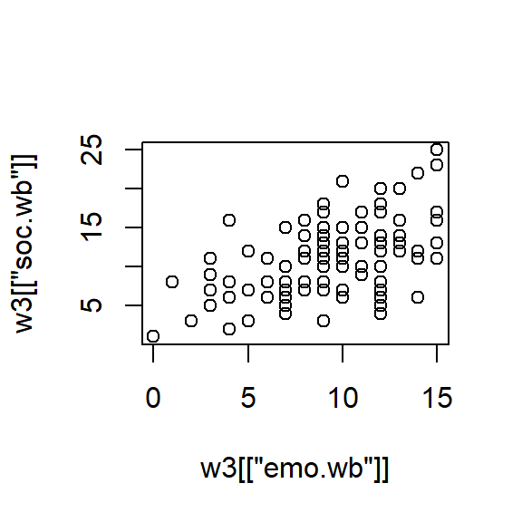

```r
plot(w3[["emo.wb"]], w3[["soc.wb"]])
```

## Auto correlation plotter

### base plot

- x, y 축 이름 추가

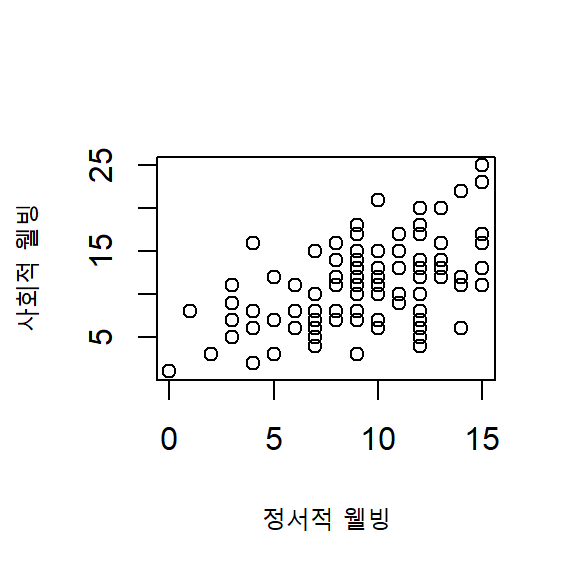

```r
plot(
    w3[["emo.wb"]], # x axis
    w3[["soc.wb"]], # y axis
    xlab = "정서적 웰빙", # x axis label
    ylab = "사회적 웰빙" # y axis label
    )
```

## Auto correlation plotter

### base plot

- 회귀선 추가

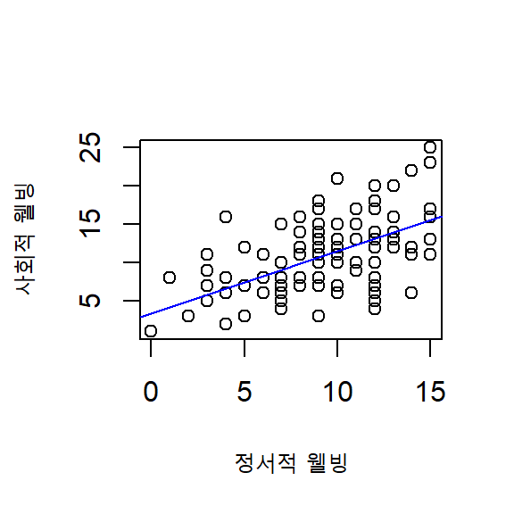

```r
plot(
    w3[["emo.wb"]], # x axis
    w3[["soc.wb"]], # y axis
    xlab = "정서적 웰빙", # x axis label
    ylab = "사회적 웰빙" # y axis label
    )
abline(lm(w3[["soc.wb"]]~w3[["emo.wb"]]), col="blue")
```

## Plotting

### saving plot

- png("파일이름") : 파일이름.png 형태로 입력
- 출력: dev.off()
- plot을 저장할 때 필요한 것
  - File name & Path
  - Size & Resolution
  - etc.

## Plotting

### saving plot

- png("파일이름.png")
- 출력: dev.off()
- 예시

```r
png("파일이름.png") # 시작

plot 관련 코드

dev.off() # 종료
```

## Plotting

### saving plot

```r
png("plot1.png") # 시작

plot(
    w3[["emo.wb"]], # x axis
    w3[["soc.wb"]], # y axis
    xlab = "정서적 웰빙", # x axis label
    ylab = "사회적 웰빙" # y axis label
    )
abline(lm(w3[["soc.wb"]]~w3[["emo.wb"]]), col="blue")

dev.off() # 종료
```

## Plotting

### base plot

- **Quiz.** w3 전체 변인들의 상관 분석 후 유의한 변인 간의 scatter plot만을 저장해보세요. (p1)
  - 어떤 작업들이 필요할까?

## Plotting

### base plot

- **Quiz.** w3 전체 변인들의 상관 분석 후 유의한 변인 간의 scatter plot만을 저장해보세요. (p1)
  - 서로 다른 두 수치 변인 선택
  - 상관 분석 실시
  - 상관 계수의 유의도가 0.05 이하인 경우
    - 파일명 자동 작성
    - plot 저장 시작: png("파일명")
    - plot 작성
    - plot 저장 종료: dev.off()

## Plotting

### base plot

- **Quiz.** w3의 모든 두 수치변인 사이의 관계를 나타내는 scatter plot 출력해보세요. (5p)
- hint:
  - for loop를 사용해 두 수치 변인 선택
  - for loop 속에서 scatter plot 출력
  - scatter plot 출력 시 xlab 과 ylab을 names()와 i, j를 활용해 자동 변화
  - scatter plot 출력 시 회귀선을 i, j를 활용해 자동 변화

## Plotting

### base plot

- **Quiz.** w3의 모든 두 수치변인 사이의 관계를 나타내는 scatter plot 출력해보세요. (5p)

```r
for (i in 1:ncol(w3)) {
    for (j in 1:ncol(w3)) {
        if (is.numeric(w3[[i]]) & is.numeric(w3[[j]]) & i != j) {
        plot(w3[[i]],
        w3[[j]],
        xlab = names(w3)[i],
        ylab = names(w3)[j])
        abline(lm(w3[[j]] ~ w3[[i]]), col = "blue")
        }
    }
}
```

## Plotting

### base plot

- 파일명 자동 작성
- paste() 함수 사용
  - sep은 각 요소 사이를 어떻게 할 것인지를 지정하는 argument

```r
chr1 <- "고려대학교"
chr2 <- "심리학과"
paste(chr1, chr2) ; paste(chr1, chr2, sep = "") ; paste(chr1, chr2, sep = "_")
```

```
## [1] "고려대학교 심리학과"
```

```
## [1] "고려대학교심리학과"
```

```
## [1] "고려대학교_심리학과"
```

## Plotting

### base plot

- 4번째 변인과 5번째 변인으로 만들어진 파일명

```r
file_names <- paste(names(w3)[4], " X ", names(w3)[5], ".png", sep="")
print(file_names)
```

```
## [1] "soc.wb X psy.wb.png"
```

## Plotting

### base plot

- **Quiz.** w3의 두 변인 사이의 scatter plot의 파일명은 어떻게 만들 수 있을까요? (2p)

## Plotting

### base plot

- **Quiz.** w3의 두 변인 사이의 scatter plot의 파일명은 어떻게 만들 수 있을까요? (2p)

```r
for (i in 1:ncol(w3)) {
    for (j in 1:ncol(w3)) {
    if (is.numeric(w3[[i]]) & is.numeric(w3[[j]])  & i != j) {
    file_name <-
    paste(names(w3)[i], " X ", names(w3)[j], ".png", sep = "")
    }
    }
}
```

## Auto correlation plotter

### base plot

- **Quiz.** 다음의 명령을 수행하는 코드를 작성하세요. (4p)
  - w3의 각 변인간 상관분석 실시
  - 두 변인 간 상관이 유의한 경우 상관계수 및 유의도 저장
  - 두 변인 간 상관이 유의한 경우 plot 저장

```r
whole.data <- data.frame()
for (i in 1:ncol(w3)) {
    for (j in 1:ncol(w3)) {
        if (is.numeric(w3[[i]]) & is.numeric(w3[[j]])  & i != j) {
            r <- cor.test(w3[[i]], w3[[j]])
            p.value <- r$p.value
            if (p.value < 0.05) {
                p.value <- round(p.value, 2)
                cor <- round(r$estimate, 2)
                data <- data.frame(names(w3)[i], names(w3)[j], cor, p.value)
                whole.data <- rbind(whole.data, data)
                file_name <- paste(names(w3)[i],
                                   " X ",
                                   names(w3)[j],
                                   ".png", sep = "")
                png(file_name)
                plot(w3[[i]],
                     w3[[j]],
                     xlab = names(w3)[i],
                     ylab = names(w3)[j])
                abline(lm(w3[[j]] ~ w3[[i]]), col = "blue")
                dev.off()
            }
        }
    }
}
```

## Auto correlation plotter

### base plot

- 심화 버전
- 변인 별로 폴더 생성 후 plot 저장

```r
whole.data <- data.frame()
for (i in 1:ncol(w3)) {
    dir.name <- names(w3)[i]
    dir.create(dir.name)
    for (j in 1:ncol(w3)) {
        if (is.numeric(w3[[i]]) & is.numeric(w3[[j]])  & i != j) {
            r <- cor.test(w3[[i]], w3[[j]])
            p.value <- r$p.value
            if (p.value < 0.05) {
                p.value <- round(p.value, 2)
                cor <- round(r$estimate, 2)
                data <- data.frame(names(w3)[i], names(w3)[j], cor, p.value)
                whole.data <- rbind(whole.data, data)
                file_name <- paste("./", dir.name,"/",
                                   names(w3)[i]," X ",
                                   names(w3)[j],
                                   ".png", sep = "")
                png(file_name)
                plot(w3[[i]],
                     w3[[j]],
                     xlab = names(w3)[i],
                     ylab = names(w3)[j])
                abline(lm(w3[[j]] ~ w3[[i]]), col = "blue")
                dev.off()
            }
        }
    }
}
```